# Exome Sample Filtering: Remove Related Swapped Samples (f5)

Harrison Ostridge

08/03/2021

f1_exome.sample.filtering.Rmd - Remove Contaminated and Low Coverage Samples. - PC1 threshold. - <1% human contamination. - >0.5x coverage.

f2_exome.sample.filtering.Rmd - Remove Related Samples. - Remove first order relatives as estimated using ngsRelate.

f3_exome.sample.filtering.Rmd - Remove Samples Which Do Not Cluster Correctly in Demographic Analyses.** - Analyse PCAngsd and NGSadmix results. - Identify poor quality samples and sample swaps.

f4_exome.sample.filtering.Rmd - Reassign Swapped Samples - Identify samples which have been misslabeled and reassign them to their correct communities

**f5_exome.sample.filtering.Rmd - Remove Related Swapped Samples** - After reassigning swapped samples, we need to check they are not related to samples in their new (correct) communities. - This is needed because the first stage of removing relatives was ran within each of the original communities.

#### Setup

```r
rm(list=ls())
knitr::opts_knit$set(root.dir = '~/OneDrive - University College London/Projects/Ostridge_PanAf/sample_filtering/exome/')
min.cov=0.5
```

#### Library

```r
library(dplyr)
library(data.table)
library(ggplot2)
library(readxl)
library(plyr)
library(tidyr)
library(stringr)
library(igraph)
library(RColorBrewer)
library(grid)
library(gridExtra)
library(fields)
library(networkD3)
library(htmlwidgets)
```

#### Read in data

```r
# Read in metadata
f4_exome=read.csv("output/f4/f4.metadata.csv", check.names = FALSE)
## Ensure it is in the correct order
f4_exome=f4_exome[order(f4_exome$Sample),]
# Read in filter table
filter.table=read.csv("output/f3/f3.filtertable.csv", check.names = FALSE)
```

## NGSrelate

I quickly re-ran NGSrelate on only Conkouati and Mt Sangbe to check the reassigned samples are not related to any others.

```r
# Read ngsRelate output
## Combine into one big file
ngsrelate.out=data.frame()
for(com in c("c.Conkouati", "w.MtSangbe")){
  com.dir=paste0("../../ngsrelate/exome/output/f4.0.5x.c.Conkouati.w.MtSangbe_doMajorMinor.1_snp.p.1e-6_minMAF.5pct/", com, "/")
  # If the directory is not empty (some communities have 0 samples after previous filtering) read in the ngsRelate output
  if(length(list.files(com.dir, pattern=".ngsrelate.out$"))!=0){
    com.result=read.table(paste0(com.dir, com, ".ngsrelate.out"), header=T)
    # Combine results from each community into one large file
    ngsrelate.out=rbind(ngsrelate.out, com.result)
  }
}
#ngsrelate.out
```

Claudia said she identified first order relatives as pairs with a theta >0.1875 (emailed on 16/03/2021).

```r
# Pull out related pairs
related.pairs=ngsrelate.out[ngsrelate.out$theta>0.1875,c("ida", "idb", "theta")]
# Remove file suffix from id columns to leave Sample names
related.pairs$ida=gsub('_exome.addRG.bam', '', related.pairs$ida)
related.pairs$idb=gsub('_exome.addRG.bam', '', related.pairs$idb)
related.pairs
```

```
##        ida     idb    theta
## 8 CMNP1-24 Con2-80 0.314878
```

```r
f4_exome[f4_exome$Sample=="CMNP1-24" | f4_exome$Sample=="Con2-80", ]
```

```
##       Sample Sample Type      Site Country Subspecies        hDNA
## 78  CMNP1-24       Feces Conkouati   Congo    Central  0.07586207
## 108  Con2-80       Feces Conkouati   Congo    Central 40.86000000
##     Average Fragment Size GQN (Fragmentation Score) Longitude  Latitude
## 78                   3062                       4.9  11.19913 -3.947262
## 108                  6729                       7.2  11.19913 -3.947262
##     Method for hDNA quantification   Coverage Human Contamination (%)
## 78                            qPCR  0.8379489                   0.195
## 108                        Shotgun 48.2998946                   0.103
##     SD1 (Human Contamination) SD2  (Human Contamination)
## 78                      0.045                      0.344
## 108                     0.076                      0.131
##     Num Position  (Human Contamination)
## 78                                57669
## 108                              213758
##                                                                           BAM.mapped.on.target
## 78  /home/ucfajos/Scratch/data/phase1and2_exomes/BAM.mapped.on.target/CMNP1-24_exome.addRG.bam
## 108  /home/ucfajos/Scratch/data/phase1and2_exomes/BAM.mapped.on.target/Con2-80_exome.addRG.bam
##       Community       f0.PC1 f2.pca.probem.samples
## 78  c.Conkouati 9.815152e-05              CMNP1-24
## 108 c.Conkouati 3.919876e-03
```

CMNP1-24 is actually a relative of Con2-80 and Con2-80 has a far higher coverage so I will just discard CMNP1-24.

```r
f5_exome=f4_exome
f5_exome=f5_exome[f5_exome$Sample!="CMNP1-24",]

filter.table=rbind(filter.table, c("f5", paste0("Reassigned non-Relatives"),
                                   nrow(f5_exome),
                                   paste0(round(nrow(f5_exome)/(as.numeric(filter.table[1, 'Number of Samples']))*100, digits = 2), "%")))
# Write filter table
write.csv(filter.table, paste0("output/f5/f5.filtertable.csv"), row.names=F)
```

### Get stats

```r
# Sample sizes
cat("Number of communities: ", length(unique(f5_exome$Community)), "\n")
```

```
## Number of communities:  44
```

```r
freq.per.group=data.frame(table(f5_exome$Community))
cat("Mean samples per community: ", mean(freq.per.group$Freq),
    "\nMax samples per community: ", max(freq.per.group$Freq),
    "\nMin samples per community: ", min(freq.per.group$Freq), "\n")
```

```
## Mean samples per community:  9.431818
## Max samples per community:  17
## Min samples per community:  1
```

```r
table(unique(f5_exome[c('Community', 'Subspecies')])$Subspecies)
```

```
##
##          Central          Eastern Nigeria-Cameroon          Western
##                7               11                4               22
```

```r
# Coverage
cat(" Mean coverage per site:", mean(f5_exome$Coverage), "\n",
    "Median coverage per site:", median(f5_exome$Coverage), "\n",
    "Minimum coverage per site:", min(f5_exome$Coverage), "\n",
    "Maximum coverage per site:", max(f5_exome$Coverage))
```

```
##  Mean coverage per site: 9.06278
##  Median coverage per site: 4.961617
##  Minimum coverage per site: 0.5092046
##  Maximum coverage per site: 69.50464
```

## Write files

```r
write.table(f5_exome, "output/f5/f5.metadata.csv", sep=",", row.names=FALSE, col.names=TRUE, quote=FALSE)
```

```r
# Frequency per group
freq.per.com=data.frame(table(f5_exome$Community))
# Rename columns
colnames(freq.per.com)=c("Community", "Freq")

write.table(freq.per.com, "output/f5/f5_freq.per.com.csv", sep=",", row.names=FALSE, col.names=TRUE, quote=FALSE)
```

### Write BAM file lists

#### All

```r
# Ensure it is ordered according to sample name
f5_exome=f5_exome[order(f5_exome$Sample),]
# All
write.table(f5_exome$BAM.mapped.on.target,
            paste0("output/bam.filelists/exome/f5_pc1_hc.1pct_coverage.0.5x_rm.rel_rm.outliers_sort.swaps_rm.rel/bam.filelist.all"),
            row.names=FALSE, col.names=FALSE, quote=FALSE)
```

#### Subspecies

```r
# Central
write.table(f5_exome[f5_exome$Subspecies=="Central",]$BAM.mapped.on.target,
            paste0("output/bam.filelists/exome/f5_pc1_hc.1pct_coverage.0.5x_rm.rel_rm.outliers_sort.swaps_rm.rel/bam.filelist.c"),
            row.names=FALSE, col.names=FALSE, quote=FALSE)
# Eastern
write.table(f5_exome[f5_exome$Subspecies=="Eastern",]$BAM.mapped.on.target,
            paste0("output/bam.filelists/exome/f5_pc1_hc.1pct_coverage.0.5x_rm.rel_rm.outliers_sort.swaps_rm.rel/bam.filelist.e"),
            row.names=FALSE, col.names=FALSE, quote=FALSE)
# Nigeria-Cameroon
write.table(f5_exome[f5_exome$Subspecies=="Nigeria-Cameroon",]$BAM.mapped.on.target,
            paste0("output/bam.filelists/exome/f5_pc1_hc.1pct_coverage.0.5x_rm.rel_rm.outliers_sort.swaps_rm.rel/bam.filelist.n"),
            row.names=FALSE, col.names=FALSE, quote=FALSE)
# Western
write.table(f5_exome[f5_exome$Subspecies=="Western",]$BAM.mapped.on.target,
            paste0("output/bam.filelists/exome/f5_pc1_hc.1pct_coverage.0.5x_rm.rel_rm.outliers_sort.swaps_rm.rel/bam.filelist.w"),
            row.names=FALSE, col.names=FALSE, quote=FALSE)
```

```r
coms=unique(f5_exome$Community)
for(com in coms){
  f5_exome.com=f5_exome[f5_exome$Community==com, ]
  write.table(f5_exome.com$BAM.mapped.on.target,
              paste0("output/bam.filelists/exome/f5_pc1_hc.1pct_coverage.0.5x_rm.rel_rm.outliers_sort.swaps_rm.rel/bam.filelist.", com),
              row.names=FALSE, col.names=FALSE, quote=FALSE)
}
```

```bash
scp -r output/bam.filelists/exome/f5_pc1_hc.1pct_coverage.0.5x_rm.rel_rm.outliers_sort.swaps_rm.rel myriad:/home/ucfajos/analysis/phase1and2_exome_analysis/angsd/bam.filelists/mapped.on.target/
```

```bash
scp -r output/bam.filelists/exome/f5_pc1_hc.1pct_coverage.0.5x_rm.rel_rm.outliers_sort.swaps_rm.rel myriad:/home/ucfajos/analysis/phase1and2_exome_analysis/angsd/bam.filelists/mapped.on.target/
```

## Write individual filter for running PCAngsd per subspecies using beagle file from all samples

```r
f5_exome$central=0
f5_exome$eastern=0
f5_exome$nigeria.cameroon=0
f5_exome$western=0

f5_exome$central[f5_exome$Subspecies == "Central"] = 1
f5_exome$eastern[f5_exome$Subspecies == "Eastern"] = 1
f5_exome$nigeria.cameroon[f5_exome$Subspecies == "Nigeria-Cameroon"] = 1
f5_exome$western[f5_exome$Subspecies == "Western"] = 1


write.table(t(f5_exome$central), "output/f5/pcangsd/c.inds",
            row.names=FALSE, col.names=FALSE, quote=FALSE)
write.table(t(f5_exome$eastern), "output/f5/pcangsd/e.inds",
            row.names=FALSE, col.names=FALSE, quote=FALSE)
write.table(t(f5_exome$nigeria.cameroon), "output/f5/pcangsd/n.inds",
            row.names=FALSE, col.names=FALSE, quote=FALSE)
write.table(t(f5_exome$western), "output/f5/pcangsd/w.inds",
            row.names=FALSE, col.names=FALSE, quote=FALSE)
```

```bash
scp output/f5/pcangsd/* myriad:/home/ucfajos/analysis/phase1and2_exome_analysis/pcangsd/ind.filters/mapped.on.target/f5/
```

### Plot samples per community

```r
plot.sample.freq=function(meta.data, group="Community", title=NULL, output.file=NULL, hlines=F){
  # Frequency per group
  freq.per.group=data.frame(table(meta.data[[group]]))
  # Rename columns
  colnames(freq.per.group)=c(group, "Freq")
  # Add subspecies information
  freq.per.group=merge(freq.per.group, unique(meta.data[,c(group, "Subspecies")]))
  # Order by frequency
  freq.per.group=freq.per.group[order(freq.per.group$Subspecies, freq.per.group$Freq),]
  # Make group type factor
  freq.per.group[[group]]=factor(freq.per.group[[group]], levels=unique(freq.per.group[[group]]))
  # Change Nigeria-Cameroon title so it fits in the plot
  freq.per.group$Subspecies[freq.per.group$Subspecies=="Nigeria-Cameroon"] = "N-C"
  # Plot
  freq.per.group.plot=ggplot(freq.per.group) +
    theme_bw() +
    geom_bar(aes(as.factor(.data[[group]]), Freq, fill=Subspecies), stat="identity") +
    facet_grid(.~Subspecies, space="free", scales="free_x") +
    theme(axis.text.x = element_text(angle = 90, vjust=0.5, hjust=1), legend.position = "none", plot.title = element_text(hjust = 0.5)) +
    labs(title=title, x=paste0(group), y = "Number of Samples") +
    scale_fill_manual(values = c('green3', 'darkorange', 'red', 'blue'))
  if(hlines==T){
    freq.per.group.plot=freq.per.group.plot+
      geom_hline(yintercept = 6, linetype="dashed")+
      geom_hline(yintercept = 8, linetype="dashed", colour="darkgrey")}
  # Save plot
  if(!is.null(output.file)){ggsave(paste0(output.file), freq.per.group.plot, height=6, width=10)}
  # Show plot
  print(freq.per.group.plot)
}
```

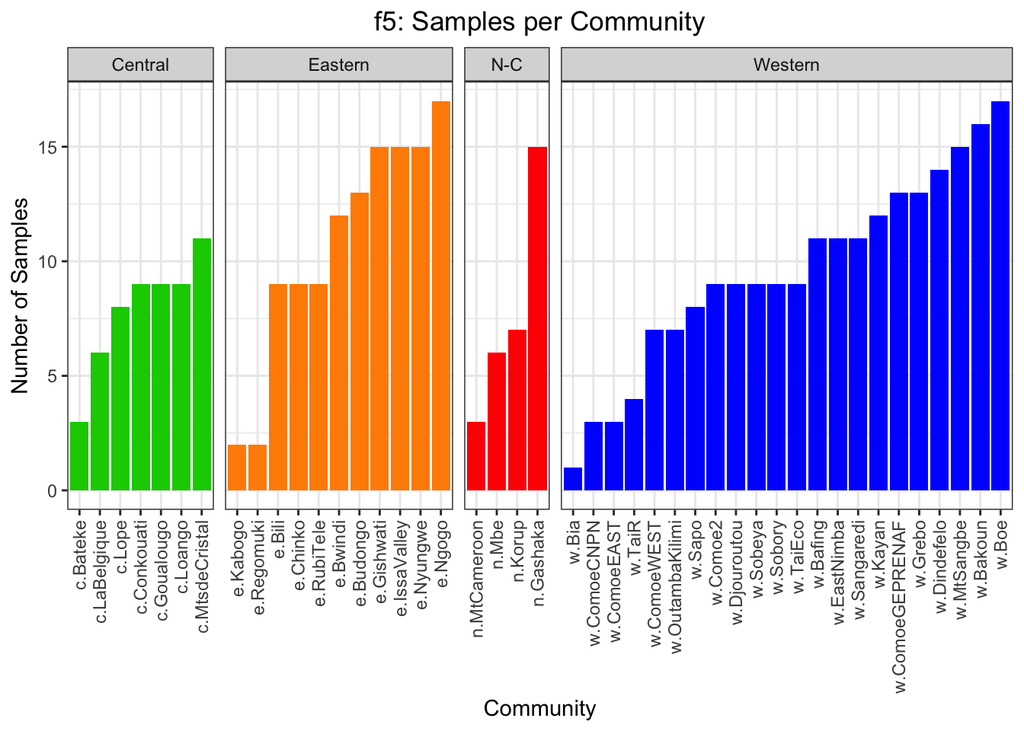

```r
plot.sample.freq(f5_exome, title="f5: Samples per Community", output.file="output/f5/f5_samples.per.com.pdf")
```

### Filter table Sankey diagram

#### sankeyNetwork

```r
filter.table$`Number of Samples`=as.numeric(filter.table$`Number of Samples`)
# Samples kept
source=filter.table[1:(nrow(filter.table)-1), 'Filter']
target=filter.table[2:nrow(filter.table), 'Filter']
n.samples=filter.table[2:nrow(filter.table), 'Number of Samples']
filtered.in.table=data.frame(source=source, target=target, value=n.samples)
filtered.in.table
```

```
##             source                   target value
## 1       Unfiltered              PC1 > -0.01   721
## 2      PC1 > -0.01         Human Cont. < 1%   533
## 3 Human Cont. < 1%          Coverage > 0.5x   467
## 4  Coverage > 0.5x             No Relatives   421
## 5     No Relatives           Pop. Structure   416
## 6   Pop. Structure Reassigned non-Relatives   415
```

```r
# Samples filtered out
n.samples=c()
for(i in 1:(nrow(filter.table)-1)){
  n.samples[i]=filter.table[i, 'Number of Samples']-filter.table[(i+1), 'Number of Samples']
}
target=c("PC1<-0.01", "Human Cont.>1%", "Coverage<0.5x", "Relatives", "Pop. Structure Outliers", "Reassigned Relatives")
filtered.out.table=data.frame(source=source, target=target, value=n.samples)

# Combine into one table
sankey.table=rbind(filtered.in.table, filtered.out.table)

# Plot Sankey diagram
# From these flows we need to create a node data frame: it lists every entities involved in the flow
nodes <- data.frame(
  name=c(as.character(sankey.table$source),
  as.character(sankey.table$target)) %>% unique()
)

# With networkD3, connection must be provided using id, not using real name like in the links dataframe.. So we need to reformat it.
sankey.table$IDsource <- match(sankey.table$source, nodes$name)-1
sankey.table$IDtarget <- match(sankey.table$target, nodes$name)-1

# Make the Network
my_color <- 'd3.scaleOrdinal() .domain(["white"]) .range(["white"])'

sankey.plot=sankeyNetwork(Links = sankey.table, Nodes = nodes,
              Source = "IDsource", Target = "IDtarget",
              Value = "value", NodeID = "name",
              sinksRight=FALSE, colourScale=my_color, fontSize= 20, nodePadding=50)
sankey.plot
```

[interactive chart not shown]

```r
# save the widget
saveWidget(sankey.plot, file=paste0("output/f5/f5_filter.sankey.diagram.html"))
```

#### ggsankey

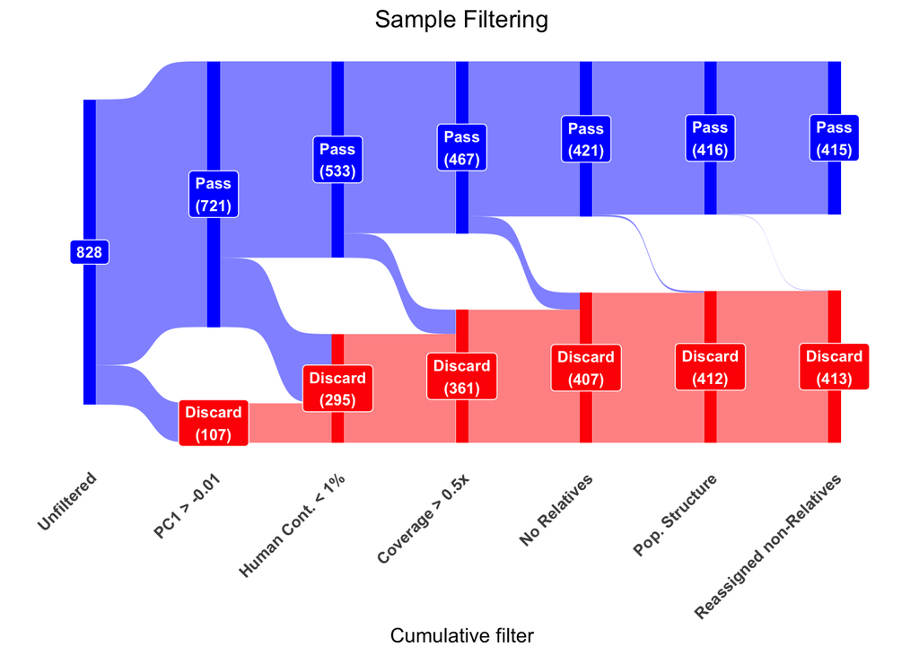

```r
# install.packages("remotes")
# remotes::install_github("davidsjoberg/ggsankey")
library(ggsankey)

sankey.df=NULL
for(filter in filter.table$Filter){
  n_pass=filter.table[filter.table$Filter==filter, "Number of Samples"]
  if(n_pass==max(filter.table$`Number of Samples`)){
    pass_lab=n_pass
  }else{
      pass_lab=paste0("Pass\n(", n_pass, ")")
  }
  n_fail=max(filter.table$`Number of Samples`)-n_pass
  fail_lab=paste0("Discard\n(", n_fail, ")")

  tmp=data.frame(column=c(rep(pass_lab, n_pass), rep(fail_lab,n_fail)))
  colnames(tmp)=filter
  if(is.null(sankey.df)){
    sankey.df=tmp
  }else{
    sankey.df=cbind(sankey.df, tmp)
  }
}
# Reshape
sankey.df=sankey.df %>%
  make_long(filter.table$Filter)

# Plot
## Prepare fill colours
nodes=unique(sankey.df$node)
fills=rep("blue", length(nodes))
names(fills)=nodes
fills[grepl("Discard", nodes)]="red"
# Plot
ggplot(sankey.df, aes(x = x,
               next_x = next_x,
               node = node,
               next_node = next_node,
               fill = factor(node),
               label = node)) +
  geom_sankey(flow.alpha = 0.5) +
  geom_sankey_label(aes(fill = factor(node)), size = 3, color = "white", fontface=2) +
  scale_fill_manual(values = fills) +
  theme_sankey() +
  labs(title="Sample Filtering", x="Cumulative filter") +
  theme(plot.title = element_text(hjust = 0.5), axis.text.x = element_text(angle = 45, hjust=1, face=2), legend.position = "none")
```

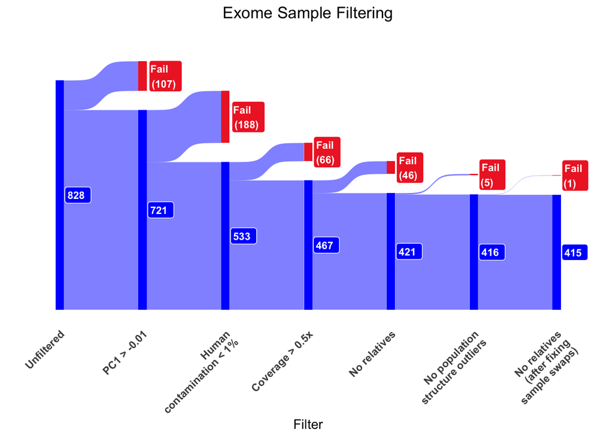

```r
#install.packages("remotes")
#remotes::install_github("davidsjoberg/ggsankey")
library(ggsankey)

filter.table.plot=filter.table
filter.table.plot[filter.table.plot$Filter=="Human Cont. < 1%", "Filter"]="Human\ncontamination < 1%"
filter.table.plot[filter.table.plot$Filter=="No Relatives", "Filter"]="No relatives"
filter.table.plot[filter.table.plot$Filter=="Pop. Structure", "Filter"]="No population\nstructure outliers"
filter.table.plot[filter.table.plot$Filter=="Reassigned non-Relatives", "Filter"]="No relatives\n(after fixing\nsample swaps)"
sankey.df=NULL
for(i in 1:nrow(filter.table.plot)){
  n_pass=filter.table.plot[i, "Number of Samples"]
  if(n_pass==max(filter.table.plot$`Number of Samples`)){
    pass_lab=paste0(n_pass)
    n_fail=0
    n_other=0
  }else{
      pass_lab=paste0(n_pass)
      n_fail=filter.table.plot$`Number of Samples`[i-1]-n_pass
      n_other=max(filter.table.plot$`Number of Samples`)-n_pass-n_fail
  }
  fail_lab=paste0("Fail\n(", n_fail, ")")
  other_lab=NA

  tmp=data.frame(column=c(rep(pass_lab, n_pass), rep(fail_lab,n_fail), rep(other_lab, n_other)))
  colnames(tmp)=filter.table.plot$Filter[i]
  if(is.null(sankey.df)){
    sankey.df=tmp
  }else{
    sankey.df=cbind(sankey.df, tmp)
  }
}
# Adding a these rows means the figure is lined up better
NAs=sankey.df[1,]
NAs[1,1:ncol(NAs)]=NA
sankey.df=rbind(sankey.df, NAs)
NAs[1,1]="a"
sankey.df=rbind(sankey.df, NAs)
#n_filt=min(filter.table.plot$`Number of Samples`)
#n_rev=max(filter.table.plot$`Number of Samples`)-n_filt
#sankey.df$Filtered=c(rep(paste0("Pass\n(", n_filt, ")"), n_filt),rep(paste0("Removed\n(",n_rev , ")"), n_rev))

# Reshape
sankey.df=sankey.df %>%
  make_long(filter.table.plot$Filter)
#sankey.df=sankey.df[!is.na(sankey.df$node),]
# Plot
## Prepare fill colours
nodes=unique(sankey.df$node)
fills=rep("blue", length(nodes))
names(fills)=nodes
fills[grepl("Fail", nodes)]="firebrick2"
fills["a"]="white"
na_fill=c("white")

# Plot
ggplot(sankey.df, aes(x = x,
               next_x = next_x,
               node = node,
               next_node = next_node,
               fill = factor(node),
               label = node)) +
  geom_sankey(flow.alpha = 0.5) +
  geom_sankey_label(aes(fill = factor(node)), size = 3, color = "white", fontface=2, hjust = -0.2) +
  scale_fill_manual(values = fills, na.value="white") +
  theme_sankey() +
  labs(title="Exome Sample Filtering", x="Filter") +
  theme(plot.title = element_text(hjust = 0.5), axis.text.x = element_text(angle = 45, hjust=1, face=2), legend.position = "none")
```

#### Simplified table for presentations

I create a simplified diagram which shows just three steps corresponding to the three main focuses of filtering: contamination, coverage and relatives. I have moved the population structure outliers to those removed due to high conbtamination as I thought this made the most sense. This diagram is just for presentations.

```r
links=data.frame(
  source=c("Unfiltered", "Unfiltered", "Low Contamination", "Low Contamination", "Coverage >0.5x", "Coverage >0.5x"),
  target=c("Low Contamination", "High Contamination", "Coverage >0.5x", "Coverage <0.5x", "No Relatives", "Relatives"),
  'Number.of.Samples'=c(528, 300, 462, 66, 415, 47),
  IDsource=c(0,0,1,1,3,3),
  IDtarget=c(1,2,3,4,5,6),
  group=c("Keep", "Discard", "Keep", "Discard", "Keep", "Discard"))
# Plot Sankey diagram
# From these flows we need to create a node data frame: it lists every entities involved in the flow
nodes=data.frame(
  name=c("Unfiltered", "Low Contamination", "High Contamination", "Coverage >0.5x", "Coverage <0.5x", "No Relatives", "Relatives"),
  #group=c("Unfiltered", "Keep", "Discard", "Keep", "Discard", "Keep", "Discard")
  group="Unfiltered")

my_color ='d3.scaleOrdinal() .domain(["Keep", "Discard", "Unfiltered"]) .range(["#69b3a2", "tomato", "black"])'

sankey.plot=sankeyNetwork(Links = links, Nodes = nodes,
              Source = "IDsource", Target = "IDtarget",
              Value = "Number.of.Samples", NodeID = "name",
              sinksRight=FALSE, colourScale=my_color, LinkGroup="group", NodeGroup="group", fontSize=30, nodePadding=50)
sankey.plot
```

[interactive chart not shown]

```r
# save the widget
saveWidget(sankey.plot, file=paste0("output/simple.filter.sankey.diagram.html"))
```